# qsmooth test

```r
library(qsmooth)
library(Rtsne)
library(ggplot2)
library(formattable)
library(tidyverse)
source('~/git/scripts/theme_Publication.R')
# https://github.com/stephaniehicks/qsmooth
load('~/git/unified_gene_expression/data/lengthScaledTPM_eye_gtex.Rdata')
source('~/git/unified_gene_expression/scripts/parse_sample_attribute.R')
```

[output not shown]

Testing to see if running qsmooth (https://github.com/stephaniehicks/qsmooth, weighted quantile normalization) improves the clustering performance.

```r
lengthScaledTPM <- lengthScaledTPM[,!(is.na(lengthScaledTPM[1,]))]
samples <- data.frame(colnames(lengthScaledTPM))
colnames(samples) <- 'sample_accession'
tissue_frame <- left_join(samples, core_info) %>% select(sample_accession, Tissue, Sub_Tissue) %>% distinct()
```

```
joining character vector and factor, coercing into character vector
```

```r
# make sure they are lined up
tissues <- left_join(samples, tissue_frame)
```

```
joining character vector and factor, coercing into character vector
```

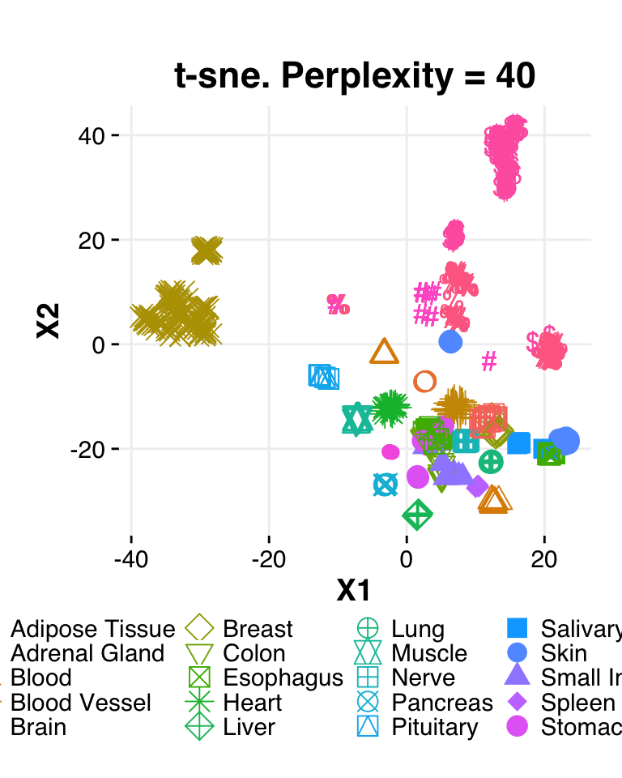

```r
# just keep the keeper set of tissues (no prostrate, etc)
sub <- tissues %>% filter(Tissue %in% keepers)
lengthScaledTPM_sub<-lengthScaledTPM[,sub$sample_accession]
qs <- qsmooth(object = lengthScaledTPM_sub,groupFactor = as.factor(sub$Tissue))
lengthScaledTPM_qsmooth <- qsmoothData(qs)
set.seed(23235)
tsne_out <- Rtsne(as.matrix(log2(t(lengthScaledTPM_qsmooth)+1)),perplexity = 40, check_duplicates = FALSE, theta=0.0 )
tsne_plot <- data.frame(tsne_out$Y)
tsne_plot$sample_accession <- colnames(lengthScaledTPM_qsmooth)
tsne_plot %>% left_join(.,core_info)  %>%
  ggplot(.,aes(x=X1,y=X2,colour=Tissue,shape=Tissue)) +
  geom_point(size=4) + scale_shape_manual(values=c(0:20,35:50)) +
  ggtitle(paste0("t-sne. Perplexity = ", 40)) +
  theme_Publication()
```

No qsmooth

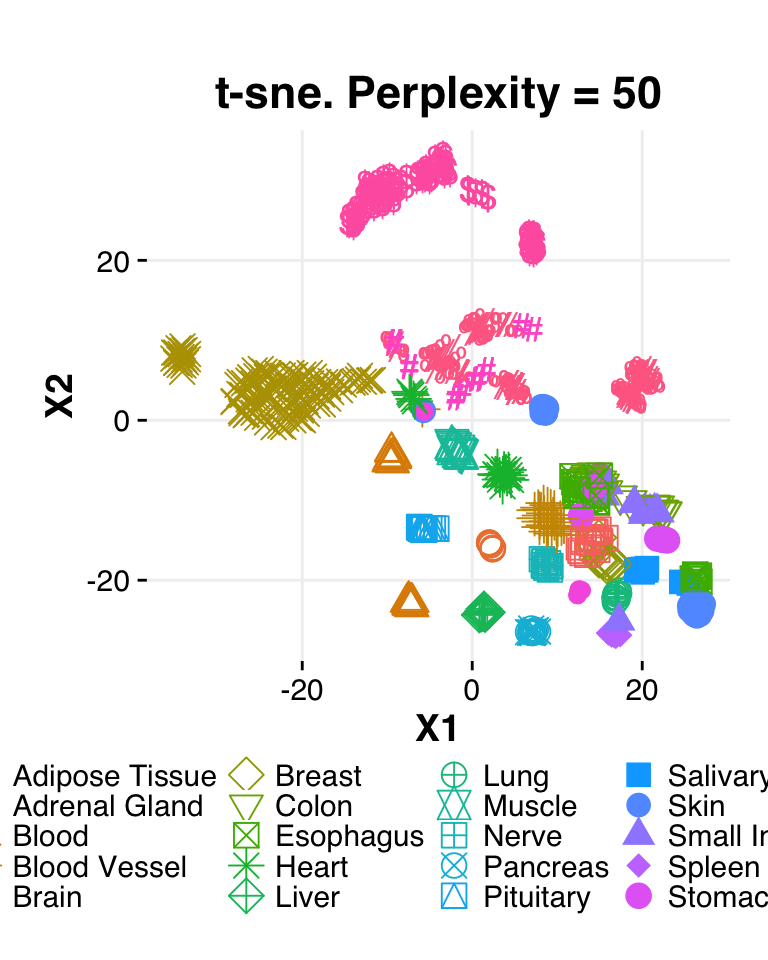

```r
set.seed(23235)
tsne_out <- Rtsne(as.matrix(log2(t(lengthScaledTPM_sub)+1)),perplexity = 40, check_duplicates = FALSE, theta=0.0 )
# Perplexity is a measure for information that is defined as 2 to the power of the Shannon entropy. The perplexity of a fair die with k sides is equal to k. In t-SNE, the perplexity may be viewed as a knob that sets the number of effective nearest neighbors. It is comparable with the number of nearest neighbors k that is employed in many manifold learners.
tsne_plot <- data.frame(tsne_out$Y)
tsne_plot$sample_accession <- colnames(lengthScaledTPM_sub)
tsne_plot %>% left_join(.,core_info)  %>%
  ggplot(.,aes(x=X1,y=X2,colour=Tissue,shape=Tissue)) +
  geom_point(size=4) + scale_shape_manual(values=c(0:20,35:50)) +
  ggtitle(paste0("t-sne. Perplexity = ", 50)) +
  theme_Publication()
```

Expression profiles without qsmooth

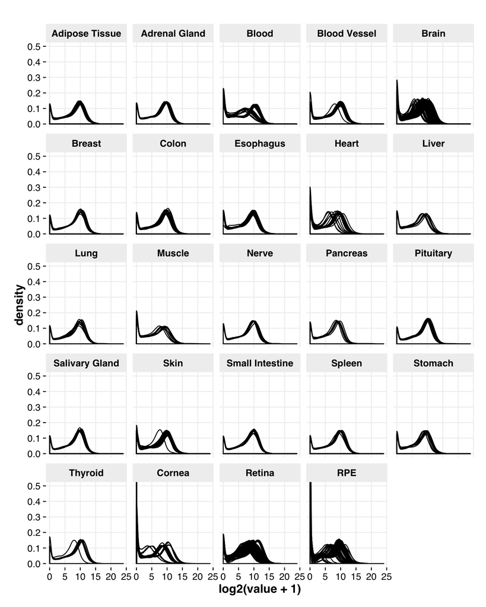

```r
gather_lST<-gather(lengthScaledTPM_sub,sample_accession) %>% left_join(.,core_tight)
ggplot(gather_lST,aes(x=log2(value+1),group=sample_accession))+geom_density()+facet_wrap(~Tissue)+coord_cartesian(ylim=c(0,0.5)) + theme_Publication()
```

Expression profiles with qsmooth. Odd spikes in the Cornea and RPE. Some weird patterns in number of lower-expressed genes (see Blood Vessel, Brain, Heart)

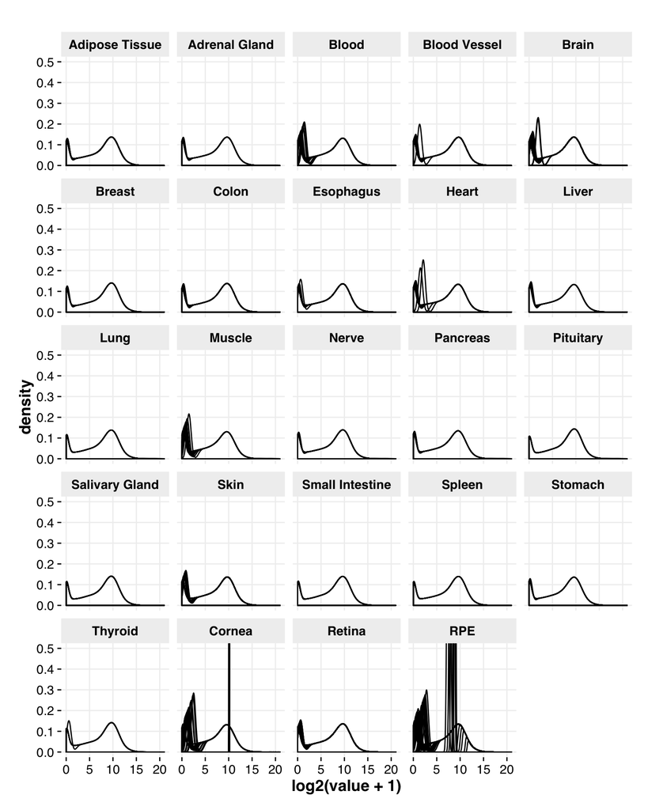

```r
core_tight2 <- core_tight
core_tight2$sample_accession <- gsub(pattern='E-MTAB-',replacement = 'E.MTAB.',core_tight$sample_accession)
gather_lST<-gather(data.frame(lengthScaledTPM_qsmooth),sample_accession) %>% left_join(.,core_tight2)
ggplot(gather_lST,aes(x=log2(value+1),group=sample_accession))+geom_density()+facet_wrap(~Tissue)+coord_cartesian(ylim=c(0,0.5))+theme_Publication()
```

Let’s look at just the Cornea. Funky.

```r
core_tight2 <- core_tight
core_tight2$sample_accession <- gsub(pattern='E-MTAB-',replacement = 'E.MTAB.',core_tight$sample_accession)
gather_lST <- gather(data.frame(lengthScaledTPM_qsmooth),sample_accession) %>% left_join(.,core_tight2) %>% filter(Tissue=='Cornea')
ggplot(gather_lST,aes(x=log2(value+1),group=sample_accession))+geom_density()+facet_wrap(~Tissue)+coord_cartesian(ylim=c(0,0.5)) + theme_Publication()
```

[output not shown]

Let’s find the weird ones. SRS390607 to SRS390610. Weird median. Plotting the uncorrected values…Huh, seems like there are lots of zeros….

```r
gather(data.frame(lengthScaledTPM_qsmooth),sample_accession) %>% left_join(.,core_tight2) %>% filter(Tissue=='Cornea') %>% group_by(sample_accession) %>% summarise(median(value)) %>% arrange(-`median(value)`) %>% head() %>% formattable()

core_eye_info %>% filter(sample_accession=='SRS390607') %>% formattable()

gather_lST<-gather(lengthScaledTPM_sub,sample_accession) %>% left_join(.,core_tight) %>% filter(sample_accession %in% c('SRS390607','SRS390608','SRS390609','SRS390610'))
ggplot(gather_lST,aes(x=log2(value+1)))+geom_density()+facet_wrap(~Tissue)+coord_cartesian(ylim=c(0,0.5)) + theme_Publication()
```

[output not shown]

Let’s look at the number level for one of those odd samples. Uh, yikes. Let’s check the median for ALL of the samples to see if any others have this problem. I’m guessing more do.

```r
summary(lengthScaledTPM_sub[,'SRS390607'])
```

```
   Min. 1st Qu.  Median    Mean 3rd Qu.    Max.
      0       0       0     320       0 6503000
```

Yeah, a few. A plateau at a median of 50.

```r
apply(lengthScaledTPM,2,function(x) median(x)) %>% sort() %>% formattable()
```

```
        SRS311706         SRS311708         SRS311709         SRS311710         SRS311711         SRS311712         SRS311713         SRS311714         SRS311715         SRS390607
                0                 0                 0                 0                 0                 0                 0                 0                 0                 0
        SRS390608         SRS390609         SRS390610         SRS311707         SRS542573         SRS542574         SRS542575         SRS542577         SRS542579         SRS542580
                0                 0                 0            0.9317             3.738              4.07             4.694             7.916             8.051             8.972
        SRS542578        SRS1146046         SRS542576         SRS912583         SRS912579         SRS333467         SRS333527         SRS389053         SRS627901         SRS912585
            9.601             11.75             12.13             13.58             13.63             15.14             15.57              16.3             16.44             18.39
        SRS526717         SRS627077         SRS912578         SRS648700         SRS389976         SRS912582        SRS1146040         SRS374843         SRS644205         SRS627356
            21.08             21.51             23.08             23.54             24.21             24.27             27.28             29.45             30.69             31.01
        SRS912580 E-MTAB-4377.RNA14         SRS626810         SRS633738 E-MTAB-4377.RNA17         SRS687010         SRS648331         SRS389359         SRS912576         SRS687009
            31.98             33.65             35.78             36.64             37.29             38.03              38.7             39.23             39.39             42.19
        SRS389911 E-MTAB-4377.RNA23         SRS526628         SRS912581         SRS374732         SRS912577         SRS374705         SRS389825         SRS687011         SRS302240
            43.47             43.52             43.59             44.41             44.72             44.82             45.69             45.88             47.63             47.71
        SRS524656         SRS648330 E-MTAB-4377.RNA16 E-MTAB-4377.RNA26         SRS644577 E-MTAB-4377.RNA18         SRS648773         SRS846897         SRS846898         SRS333587
            48.97              49.3             50.62             51.27             51.78             53.03             53.66             54.94              55.1             55.84
E-MTAB-4377.RNA13         SRS846896         SRS846886         SRS389925         SRS846887         SRS846885         SRS649748         SRS912584         SRS846888  E-MTAB-4377.RNA3
            56.31             57.37              57.9             58.56             62.26             62.39             63.97             64.12             64.55             65.27
        SRS374689         SRS846893         SRS389597         SRS846895         SRS636264         SRS846890 E-MTAB-4377.RNA29 E-MTAB-4377.RNA21         SRS333468         SRS638384
            65.37             67.25             67.34             67.61             68.36             69.15             69.93             75.45             78.62             78.96
        SRS846889         SRS645946 E-MTAB-4377.RNA15         SRS648265 E-MTAB-4377.RNA30         SRS389883         ERS214125  E-MTAB-4377.RNA8         SRS302236         SRS645955
            79.64             82.14             83.07             83.81             84.55             85.06              86.2             86.93             88.86              90.3
        SRS638031         SRS846899         SRS369432         ERS214124         SRS374971        SRS1146043 E-MTAB-4377.RNA43         SRS846894         SRS389889         SRS302239
             91.8             94.62             95.76             96.18             101.4             101.6             102.2             102.8             102.8             102.9
        SRS625747         SRS637717         SRS302243         ERS214123         SRS648758         SRS627726 E-MTAB-4377.RNA25         SRS628435         SRS846892  E-MTAB-4377.RNA1
            104.9             104.9             106.6             108.1             110.9               112             113.7             116.1             116.8             116.8
E-MTAB-4377.RNA12         SRS389592         SRS846891 E-MTAB-4377.RNA47  E-MTAB-4377.RNA7 E-MTAB-4377.RNA49         SRS524829         SRS626190         SRS402527         SRS623961
              117             117.3             117.9             118.5             119.3             119.7             120.3               121             121.1             121.4
```

[output cut: 118 more lines]

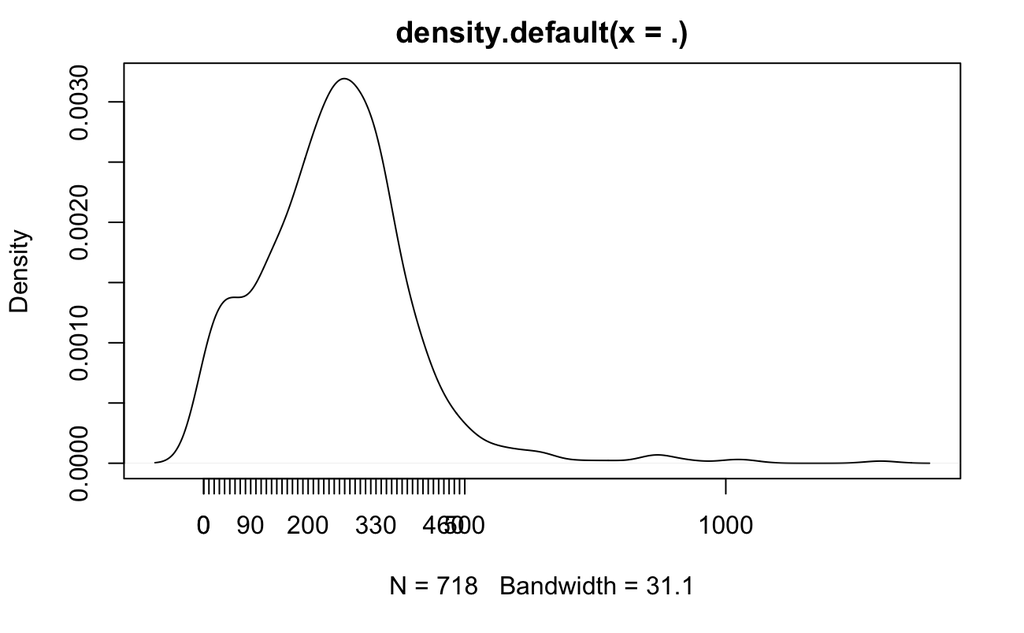

```r
apply(lengthScaledTPM,2,function(x) median(x)) %>% density() %>% plot()
axis(side = 1, at=seq(0,500,10))
```

Let’s redo the qsmooth’ed density plots above, but with the low (<10) colored. Bam, that’s it.

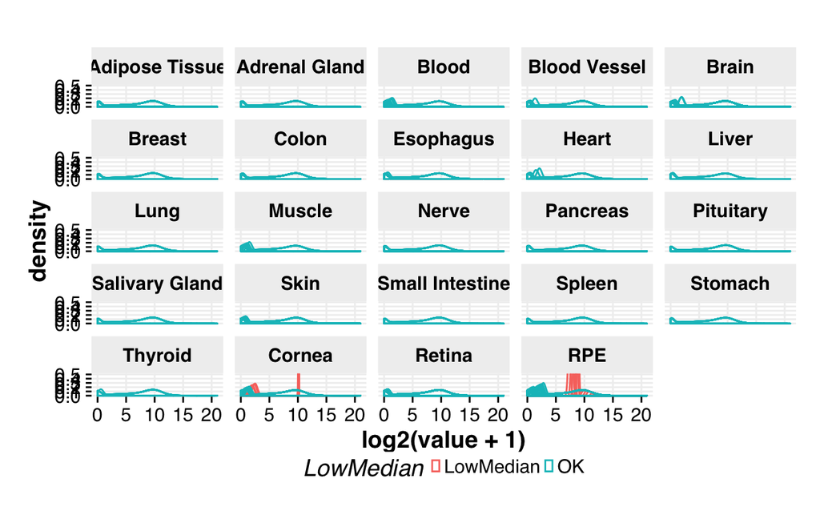

```r
median_TPM <- apply(lengthScaledTPM,2,function(x) median(x)) %>% sort() %>% formattable()
lows <- names(median_TPM[median_TPM<10])
core_tight2 <- core_tight
core_tight2$sample_accession <- gsub(pattern='E-MTAB-',replacement = 'E.MTAB.',core_tight$sample_accession)
gather_lST<-gather(data.frame(lengthScaledTPM_qsmooth),sample_accession) %>% left_join(.,core_tight2) %>% mutate(LowMedian=ifelse(sample_accession %in% lows, 'LowMedian','OK'))
ggplot(gather_lST,aes(x=log2(value+1),group=sample_accession,colour=LowMedian))+geom_density(alpha=0.5)+facet_wrap(~Tissue)+coord_cartesian(ylim=c(0,0.5))+theme_Publication()
```

```r
lows <- names(median_TPM[median_TPM<60])
```

[output not shown]

Ugh, this tosses a LOT of my fetal RPE (44 originally). Eh, life.

```r
gather_lST %>% filter(sample_accession %in% lows) %>% select(sample_accession, Tissue, Sub_Tissue) %>% distinct() %>% group_by(Tissue, Sub_Tissue) %>% summarise(Count=n()) %>% formattable()
```

| Tissue | Sub_Tissue | Count |
| --- | --- | --- |
| Blood | Whole Blood | 8 |
| Brain | Brain - Amygdala | 1 |
| Brain | Brain - Anterior cingulate cortex (BA24) | 1 |
| Brain | Brain - Frontal Cortex (BA9) | 1 |
| Brain | Brain - Hypothalamus | 1 |
| Brain | Brain - Nucleus accumbens (basal ganglia) | 2 |
| Brain | Brain - Putamen (basal ganglia) | 2 |
| Heart | Heart - Left Ventricle | 5 |
| Muscle | Muscle - Skeletal | 4 |
| Cornea | Cornea | 12 |
| RPE | fetalRPE | 19 |
| RPE | RPE | 1 |

Redo the tsne (qsmooth’ed) and tossing the above samples. Looks better. A couple of Retina ($) samples that have wandered away (X2=10,X1=-10).

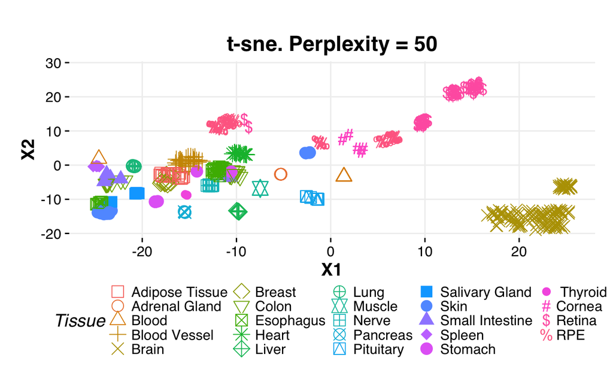

```r
set.seed(23235)
lengthScaledTPM_qsmooth_highExp <- as.matrix(lengthScaledTPM_qsmooth[,!colnames(lengthScaledTPM_qsmooth) %in% lows])
tsne_out <- Rtsne(as.matrix(log2(t(lengthScaledTPM_qsmooth_highExp)+1)),perplexity = 50, check_duplicates = FALSE, theta=0.0 )
tsne_plot <- data.frame(tsne_out$Y)
tsne_plot$sample_accession <- colnames(lengthScaledTPM_qsmooth_highExp)
tsne_plot %>% left_join(.,core_info)  %>%
  ggplot(.,aes(x=X1,y=X2,colour=Tissue,shape=Tissue)) +
  geom_point(size=4) + scale_shape_manual(values=c(0:20,35:50)) +
  ggtitle(paste0("t-sne. Perplexity = ", 50)) +
  theme_Publication()
```

Let’s do a quick check on genes with overall low experession. Less than 1 count on average across all samples, for a gene.

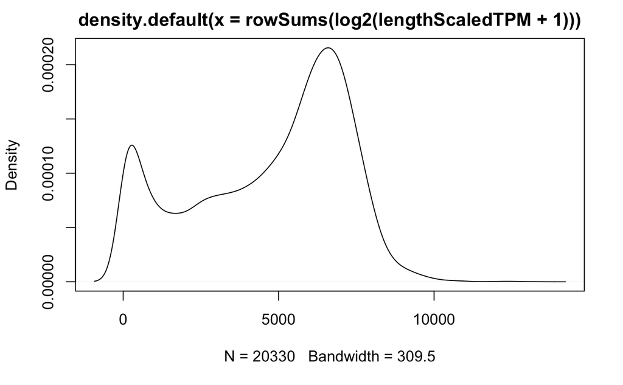

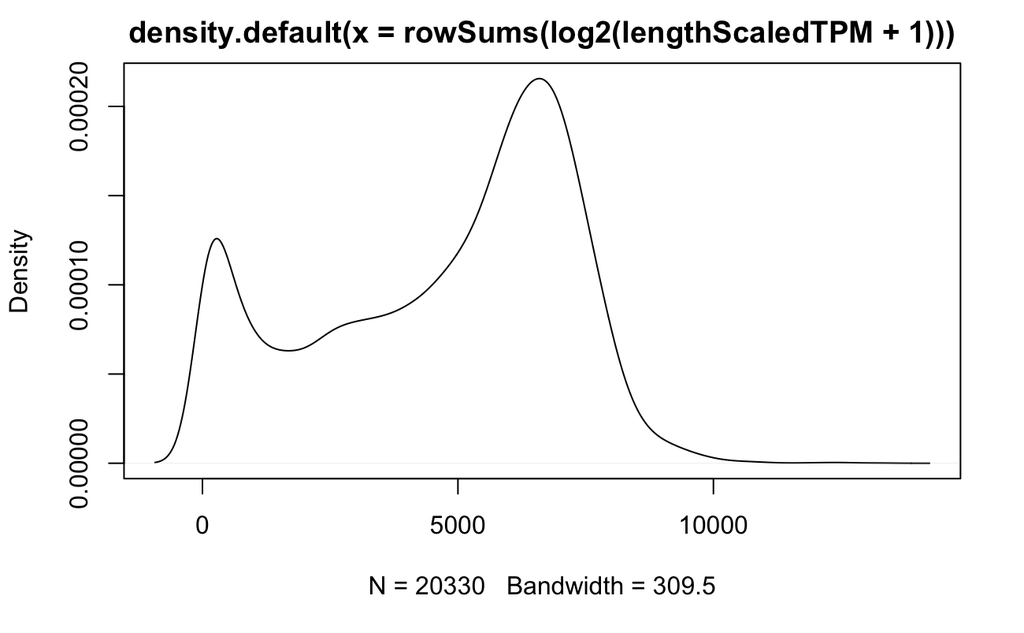

```r
density(rowSums(log2(lengthScaledTPM+1))) %>% plot()
density(rowSums(log2(lengthScaledTPM+1))) %>% plot()

table((rowSums(lengthScaledTPM)/ncol(lengthScaledTPM))<1)
```

```
FALSE  TRUE
19277  1053
```

```r
table((rowSums(lengthScaledTPM)/ncol(lengthScaledTPM))<1)
```

```
FALSE  TRUE
19277  1053
```

```r
lowly_expressed_genes <- row.names(lengthScaledTPM[(rowSums(lengthScaledTPM)/ncol(lengthScaledTPM)<1),])
```

OK, let’s also toss these and see how that changes the t-sne clustering.

```r
lengthScaledTPM_qsmooth_highExp_remove_lowGenes <- lengthScaledTPM_qsmooth_highExp[!(row.names(lengthScaledTPM_qsmooth_highExp) %in% lowly_expressed_genes),]
```

[output not shown]

OK, this is getting hard/impossible to see whether I’m doing any better. Need to get more analytical. Metric: cluster purity. K-means cluster (k number is number of sub-tissues or tissues?), check purity of each cluster.

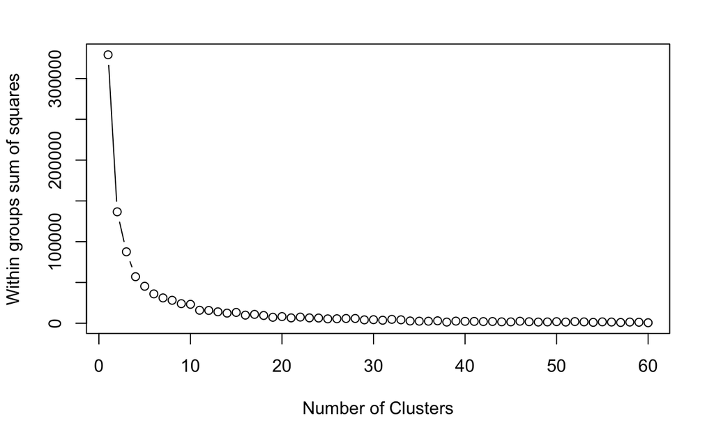

```r
load('~/git/unified_gene_expression/data/lengthScaledTPM_eye_gtex.Rdata')
lengthScaledTPM <- lengthScaledTPM[,!(is.na(lengthScaledTPM[1,]))]
sub <- tissues %>% filter(Tissue %in% keepers)
lengthScaledTPM_sub<-lengthScaledTPM[,sub$sample_accession]
set.seed(23235)
tsne_out <- Rtsne(as.matrix(log2(t(lengthScaledTPM_sub)+1)),perplexity = 40, check_duplicates = FALSE, theta=0.0 )
tsne_plot <- data.frame(tsne_out$Y)
tsne_plot$sample_accession <- colnames(lengthScaledTPM_sub)
tsne_go <- tsne_plot %>% left_join(.,core_info)
# Determine number of clusters
wss <- (nrow(tsne_go[,c('X1','X2')])-1)*sum(apply(tsne_go[,c('X1','X2')],2,var))
for (i in 2:60) wss[i] <- sum(kmeans(tsne_go[,c('X1','X2')],
    centers=i)$withinss)
plot(1:60, wss, type="b", xlab="Number of Clusters",
  ylab="Within groups sum of squares")
```

```r
# 24 is the total number of Tissues
# 48 is the total number of Sub Tissues
set.seed(23235)
fit <- kmeans(tsne_go[,c('X1','X2')], 48)
cbind(tsne_go, fit$cluster) %>% group_by(fit$cluster,Tissue) %>% summarise(Count = n()) %>% mutate(freq = Count /sum(Count)) %>% formattable()
```

| fit$cluster | Tissue | Count | freq |
| --- | --- | --- | --- |
| 1 | RPE | 12 | 1.00000000 |
| 2 | Colon | 7 | 0.63636364 |
| 2 | Small Intestine | 4 | 0.36363636 |
| 3 | Pituitary | 10 | 1.00000000 |
| 4 | Blood | 10 | 1.00000000 |
| 5 | Brain | 11 | 1.00000000 |
| 6 | Brain | 11 | 1.00000000 |
| 7 | Brain | 6 | 1.00000000 |
| 8 | Retina | 4 | 1.00000000 |
| 9 | Brain | 8 | 1.00000000 |
| 10 | Brain | 8 | 1.00000000 |
| 11 | Adrenal Gland | 9 | 0.47368421 |
| 11 | Nerve | 10 | 0.52631579 |
| 12 | Retina | 20 | 1.00000000 |
| 13 | Brain | 5 | 1.00000000 |
| 14 | Retina | 15 | 1.00000000 |
| 15 | Brain | 8 | 1.00000000 |
| 16 | Brain | 10 | 1.00000000 |
| 17 | Salivary Gland | 8 | 0.57142857 |
| 17 | Stomach | 6 | 0.42857143 |
| 18 | Blood Vessel | 13 | 1.00000000 |
| 19 | Brain | 8 | 1.00000000 |
| 20 | Colon | 4 | 0.33333333 |
| 20 | Esophagus | 8 | 0.66666667 |
| 21 | Retina | 44 | 1.00000000 |
| 22 | Brain | 6 | 1.00000000 |
| 23 | Retina | 6 | 1.00000000 |
| 24 | Retina | 19 | 1.00000000 |
| 25 | Brain | 9 | 1.00000000 |
| 26 | Colon | 4 | 0.50000000 |
| 26 | Esophagus | 1 | 0.12500000 |
| 26 | Small Intestine | 1 | 0.12500000 |
| 26 | Stomach | 2 | 0.25000000 |
| 27 | Heart | 5 | 0.14705882 |
| 27 | Cornea | 8 | 0.23529412 |
| 27 | RPE | 21 | 0.61764706 |
| 28 | Colon | 3 | 0.50000000 |
| 28 | Small Intestine | 3 | 0.50000000 |
| 29 | Blood Vessel | 1 | 0.05000000 |
| 29 | Muscle | 10 | 0.50000000 |
| 29 | Skin | 1 | 0.05000000 |
| 29 | Thyroid | 1 | 0.05000000 |
| 29 | Cornea | 7 | 0.35000000 |
| 30 | Lung | 9 | 0.45000000 |
| 30 | Small Intestine | 1 | 0.05000000 |
| 30 | Spleen | 10 | 0.50000000 |
| 31 | Cornea | 4 | 0.20000000 |
| 31 | RPE | 16 | 0.80000000 |
| 32 | Skin | 11 | 0.27500000 |
| 32 | Cornea | 9 | 0.22500000 |
| 32 | RPE | 20 | 0.50000000 |
| 33 | Esophagus | 6 | 0.85714286 |
| 33 | Stomach | 1 | 0.14285714 |
| 34 | Brain | 7 | 1.00000000 |
| 35 | Colon | 2 | 0.25000000 |
| 35 | Esophagus | 5 | 0.62500000 |
| 35 | Small Intestine | 1 | 0.12500000 |
| 36 | Blood Vessel | 15 | 1.00000000 |
| 37 | Heart | 14 | 1.00000000 |
| 38 | Liver | 9 | 0.47368421 |
| 38 | Pancreas | 10 | 0.52631579 |
| 39 | Thyroid | 8 | 1.00000000 |
| 40 | Breast | 8 | 1.00000000 |
| 41 | Blood | 10 | 1.00000000 |
| 42 | Brain | 8 | 1.00000000 |
| 43 | Brain | 6 | 1.00000000 |
| 44 | Adipose Tissue | 20 | 0.86956522 |
| 44 | Blood Vessel | 1 | 0.04347826 |
| 44 | Breast | 2 | 0.08695652 |
| 45 | Esophagus | 10 | 0.33333333 |
| 45 | Salivary Gland | 2 | 0.06666667 |
| 45 | Skin | 18 | 0.60000000 |
| 46 | Brain | 6 | 1.00000000 |
| 47 | Brain | 11 | 1.00000000 |
| 48 | RPE | 16 | 1.00000000 |

Now go deeper and count number of Tissue types and purity (highest freq) for each cluster

```r
cbind(tsne_go, fit$cluster) %>% group_by(fit$cluster,Tissue) %>% summarise(Count = n()) %>% mutate(freq = Count /sum(Count)) %>% summarise(Tissue_Count = n(), highest_freq=max(freq)) %>% formattable()
```

| fit$cluster | Tissue_Count | highest_freq |
| --- | --- | --- |
| 1 | 1 | 1.0000000 |
| 2 | 2 | 0.6363636 |
| 3 | 1 | 1.0000000 |
| 4 | 1 | 1.0000000 |
| 5 | 1 | 1.0000000 |
| 6 | 1 | 1.0000000 |
| 7 | 1 | 1.0000000 |
| 8 | 1 | 1.0000000 |
| 9 | 1 | 1.0000000 |
| 10 | 1 | 1.0000000 |
| 11 | 2 | 0.5263158 |
| 12 | 1 | 1.0000000 |
| 13 | 1 | 1.0000000 |
| 14 | 1 | 1.0000000 |
| 15 | 1 | 1.0000000 |
| 16 | 1 | 1.0000000 |
| 17 | 2 | 0.5714286 |
| 18 | 1 | 1.0000000 |
| 19 | 1 | 1.0000000 |
| 20 | 2 | 0.6666667 |
| 21 | 1 | 1.0000000 |
| 22 | 1 | 1.0000000 |
| 23 | 1 | 1.0000000 |
| 24 | 1 | 1.0000000 |
| 25 | 1 | 1.0000000 |
| 26 | 4 | 0.5000000 |
| 27 | 3 | 0.6176471 |
| 28 | 2 | 0.5000000 |
| 29 | 5 | 0.5000000 |
| 30 | 3 | 0.5000000 |
| 31 | 2 | 0.8000000 |
| 32 | 3 | 0.5000000 |
| 33 | 2 | 0.8571429 |
| 34 | 1 | 1.0000000 |
| 35 | 3 | 0.6250000 |
| 36 | 1 | 1.0000000 |
| 37 | 1 | 1.0000000 |
| 38 | 2 | 0.5263158 |
| 39 | 1 | 1.0000000 |
| 40 | 1 | 1.0000000 |
| 41 | 1 | 1.0000000 |
| 42 | 1 | 1.0000000 |
| 43 | 1 | 1.0000000 |
| 44 | 3 | 0.8695652 |
| 45 | 3 | 0.6000000 |
| 46 | 1 | 1.0000000 |
| 47 | 1 | 1.0000000 |
| 48 | 1 | 1.0000000 |

OK, now take the mean of Tissue_Count and highest_freq, for two metrics for each tnse.

```r
cbind(tsne_go, fit$cluster) %>% group_by(fit$cluster,Tissue) %>% summarise(Count = n()) %>% mutate(freq = Count /sum(Count)) %>% summarise(Tissue_Count = n(), highest_freq=max(freq)) %>% mutate(mean(Tissue_Count), mean(highest_freq)) %>% select(`mean(Tissue_Count)`, `mean(highest_freq)`) %>% distinct()
```

| mean(Tissue_Count) | mean(highest_freq) |
| --- | --- |
| 1.5625 | 0.8707593 |

Cool. Let’s go the end (qsmooth, removal of low-median samples, removal of low expression genes) and see if these metrics get better. YES THEY DO. IT WORKS. OMG. (Sorry, usually stuff like this blows up in my face once I test it rigorously).

| mean(Tissue_Count) | mean(highest_freq) |
| --- | --- |
| 1.333333 | 0.9235636 |